# Movilidad intercomunal y educación superior en la Provincia de Valparaíso

Kevin Licón

2025-10-18

# 1. Introducción

El territorio se transforma constantemente a medida que cambian las relaciones sociales, las políticas públicas y las dinámicas del mercado. En la Provincia de Valparaíso, estos procesos se expresan a través de una geografía desigual, donde la estructura metropolitana combina sectores con alta concentración de bienes y servicios -como Valparaíso y Viña del Mar- y otras que dependen de ellas para acceder a educación, salud y empleo.

La movilidad intercomunal permite comprender el grado de integración funcional entre estos territorios. Los desplazamientos generalmente responden a diferentes variables y contextos, de acuerdo a las diferentes realidades de la población. Habitualmente se tiende a pensar únicamente en la migración desde lo rural a lo urbano, pero resulta imperioso observar cómo han cambiado estas dinámicas, aún más después del fenómeno de la pandemia del COVID-19, donde las personas cambiaron algunas tendencias, movilizándose a zonas alejadas de la urbe con las nuevas posibilidades que presentaba el trabajo telemático. Este último fenómeno se observó principalmente en personas con estudios superiores, los cuales en varios casos las labores que realizan son llevadas a cabo a través de un computador. También es importante considerar las necesidades de las nuevas generaciones, donde alejarse de las zonas más aglomeradas se convierte en una tendencia cada vez mayor, pero a la vez esto no implica que esta población quiera renunciar a la accesibilidad en bienes y servicios propios de las zonas más urbanizadas.

A su vez, resulta interesante estudiar como variable la educación superior de la población, donde aparecen fenómenos esperables como una distribución espacial que no es uniforme: las zonas con alta concentración de población con estudios superiores suelen ser también las que experimentan procesos de renovación urbana o gentrificación, donde la llegada de nuevos habitantes con mayor nivel educativo y, por consecuencia, de ingresos mayores, reconfigura el tejido social y el uso del territorio.

En este contexto, el presente estudio busca analizar la relación entre la movilidad intercomunal y el nivel educativo en la Provincia de Valparaíso, observando cómo ambas dimensiones se entrelazan para reflejar las problemáticas planteadas. A partir de los datos obtenidos del Censo 2017, se busca identificar los territorios donde estas variables convergen, revelando las posibles tendencias de reconfiguración social y territorial dentro del sistema metropolitano porteño.

Este enfoque permite vincular las variables a través de un análisis bivariado, el cual contribuye a comprender como la educación y movilidad se combinan en los procesos contemporáneos de cambio urbano, en los que la gentrificación aparece como una manifestación de las nuevas formas de desigualdad espacial en el territorio.

# 2. Objetivos

## 2.1. Objetivo General

Analizar la relación entre la movilidad intercomunal residencial y la población con educación superior en la Provincia de Valparaíso, con el propósito de identificar patrones territoriales asociados a procesos de reconfiguración urbana y posibles manifestaciones de gentrificación.

## 2.2. Objetivos Específicos

1. Caracterizar espacialmente la distribución de población con estudios superiores y la movilidad intercomunal residencial.
2. Explorar la relación estadística entre ambas variables, identificando tendencias generales y posibles asociaciones significativas.
3. Elaborar representaciones cartográficas bivariadas que integren ambas dimensiones, permitiendo visualizar los contrastes.
4. Interpretar los resultados desde una perspectiva territorial, relacionando los patrones observados con fenómenos contemporáneos como la redistribución residencial, valorización urbana y gentrificación.

# 3. Metodología

El análisis se desarrolló principalmente bajo un enfoque cuantitativo y espacial, orientado a examinar la relación entre la movilidad intercomunal y el nivel educativo de la población en la Provincia de Valparaíso. Se utilizó información proveniente del Censo 2017, procesada mediante R y datos almacenados en una base PostgreSQL/PostGIS, complementando el análisis estadístico con técnicas de visualización cartográfica. A continuación, se desarrollarán aspectos metodológicos destacables del proceso.

## 3.1 Librerías

Para la realización del trabajo se utilizó como entorno de programación R (versión 4.5.1), complementando con un conjunto de librerías que permiten la conexión a bases de datos, manipulación de datos espaciales y visualización estadística.

```r
library(DBI)
library(RPostgres)
library(sf)
library(ggplot2)
library(RColorBrewer)
library(cowplot)
library(biscale)
```

Estas herramientas logran obtener un flujo de análisis más acabado, desde la conexión a la base de datos hasta la generación de representaciones cartográficas.

## 3.2 Conexión Base de Datos

Los datos provenientes del Censo 2017 fueron almacenados en una base de datos PostgreSQL, donde además se añadió la extensión PostGIS, la cual permite el manejo de geometrías espaciales. Dicho complemento fue necesario para poder espacializar los datos del censo, por lo cual a partir de archivos *geojson* cargados en el software QGIS, se incorpora una conexión con la base de datos con información geométrica.

La conexión con R se estableció mediante el paquete `RPostgres` con parámetros locales de host, puerto, usuario, contraseña y nombre de la base de datos, como se muestra a continuación:

```r
con = dbConnect(
  Postgres(),
  dbname = db_name,
  host = db_host,
  port = db_port,
  user = db_user,
  password = db_password
)
```

A partir de esta conexión se ejecutaron consultas SQL que permitieron obtener la siguiente información:

- Zonas censales con sus geometrías.
- La tabla de indicadores demográficos.
- Capa de límites comunales para referencia visual.

El almacenamiento a través del gestor de bases de datos permitió realizar cruces de información espacial de una forma eficiente y mantener a su vez la consistencia geométrica.

## 3.3 Indicadores

Para la realización del estudio se construyeron dos indicadores a partir de los datos del Censo de Población y Vivienda 2017, los cuales fueron expresados en porcentaje.

### 3.3.1 Porcentaje de Movilidad Intercomunal Residencial (MIR)

Este indicador tiene como propósito cuantificar la proporción de personas que, en el momento del Censo 2017, residían en una comuna diferente a la actual cinco años antes del levantamiento censal.

A través de este indicador se pueden representar los cambios de residencia habitual entre comunas, asociado a procesos de redistribución poblacional.

$$\text{MIR (%)} =
\left(
\frac{P_{\text{migrantes}}}{P_{\text{total}}}
\right) \times 100$$

Donde:

$P_{\text{migrantes}}$ = personas que cambiaron de comuna en los últimos cinco años. Las variables consideradas del censo son: `p10`, que toma el valor de `1` para aquellas personas que fueron censadas en su residencia habitual; y `p11`, que indica cuando la persona residía en otra comuna en los últimos 5 años cuando toma el valor de `3`.

$P_{\text{total}}$ = población total de la zona censal.

A continuación, se presenta la parte de la query en `SELECT` que invoca al indicador:

```sql
ROUND(
    COUNT(*) FILTER (
        WHERE p.p10 = 1
        AND p.p11 = 3
    ) * 100.0 / COUNT(*), 2)
    AS ptje_mov_intercomunal
```

### 3.3.2 Porcentaje de Población con Educación Superior (PES)

Por otra parte, este indicador representa la proporción de personas con educación técnica o universitaria completa o incompleta, en relación con el total de población censada en cada zona.

$$\text{PES (%)} =
\left(
\frac{P_{\text{ed_sup}}}{P_{\text{total}}}
\right) \times 100$$

$P_{\text{ed_sup}}$ = número de personas que declararon haber cursado estudios de nivel técnico o universitario. En este caso se consideró a la población mayor de edad a través de la variable censal `p09`, mientras que la variable correspondiente a años de estudios `escolaridad` se filtraron aquellos valores iguales o superiores a 13, ya que en Chile la educación básica y media tiene una duración de 12 años.

$P_{\text{total}}$ = población total residente mayor de edad en la zona censal.

A continuación, se presenta el `SELECT` en la query que contempla este indicador:

```sql
ROUND(
    COUNT(*) FILTER (
        WHERE p.p09 >= 18
        AND p.escolaridad >= 13
    ) * 100.0 / COUNT(*) FILTER (
        WHERE p.p09 >= 18
    ), 2)
    AS ptje_ed_superior
```

## 3.4 Desagregación Espacial

La unidad de análisis de realizó a nivel de zona censal, la cual permite captar con mayor detalle las diferencias intracomunales y los contrastes entre áreas urbanas, periurbanas y rurales.

La elección se fundamenta principalmente en la capacidad para reflejar las variaciones internas dentro de cada comuna, especialmente en un territorio complejo con es la provincia de Valparaíso.

Durante la etapa de preparación espacial, se identificó una problemática asociada a las zonas insulares pertenecientes a algunas comunas de la provincia. Si bien existe el caso de Rapa Nui y Juan Fernández, ambos casos insulares son comunas por si sola que se pueden filtrar rápidamente. Caso contrario ocurre con las Islas Salas y Gómez, las cuales pertenecen administrativamente al territorio continental de Valparaíso. Estas porciones, al ser geométricamente discontinuas y carentes de población censada, generaban interferencias en los procesos de intersección espacial y en la eventual visualización de los resultados cartográficos.

Para abordar dicha situación, se implementó un filtro espacial mediante SQL, cuyo propósito principal fue mantener únicamente las partes continentales de cada comuna, seleccionado el polígono de mayor tamaño y excluyendo las zonas insulares.

```sql
comunas_mainland AS (
  WITH partes AS (
    SELECT nom_comuna, (ST_Dump(geom)).geom AS geom
    FROM dpa.comunas_v
    WHERE nom_provin = 'VALPARAÍSO'
      AND nom_comuna <> 'JUAN FERNÁNDEZ'
  ),
  ranked AS (
    SELECT nom_comuna, geom,
           ROW_NUMBER() OVER (
             PARTITION BY nom_comuna
             ORDER BY ST_Area(ST_Transform(geom, 32719)) DESC
           ) AS rn
    FROM partes
  )
  SELECT nom_comuna, geom
  FROM ranked
  WHERE rn = 1
),

mainland AS (
  SELECT ST_Union(geom) AS geom
  FROM comunas_mainland
)
SELECT
  a.geocodigo,
  shp.geom,
  a.nom_comuna,
  a.ptje_mov_intercomunal,
  a.ptje_ed_superior
FROM agg a
JOIN dpa.zonas_censales_v AS shp
  ON a.geocodigo = shp.geocodigo
JOIN mainland m
  ON ST_Intersects(shp.geom, m.geom);
```

## 3.5 Visualización

La visualización también se llevó a cabo en el entorno RStudio, utilizando principalmente las librerías `ggplot2`, `sf`, `biscale` y `cowplot`.

El propósito fue representar gráficamente la relación entre la MIR y la PES, combinando enfoques estadísticos y geoespaciales.

Para el estudio estadístico se realizaron histogramas por cada una de las variables, a la vez que se combinaron en un gráfico de dispersión para observar la tendencia. Luego se elaboraron cartografías para cada variable, mostrando espacialmente como se distribuyen estas, para finalizar con el mapa bivariado, aplicando una clasificación de tres categorías por variable (baja, media y alta) según el método de Jenks.

# 4. Resultados y Análisis

## 4.1 Resultados MIR

El histograma para el % de movilidad intercomunal residencial muestra una distribución asimétrica hacia la derecha, con una concentración importante de zonas censales en torno al 10%. Esto indica que gran parte de las zonas de la provincia presentan niveles bajos de cambio de residencia entre comuna, lo que refleja cierta estabilidad poblacional o una baja atracción migratoria. Desde el 20%, la frecuencia disminuye progresivamente, indicando que son pocos los sectores que concentran alta movilidad residencial.

Los valores elevados tienen a corresponder, por regla general, a las áreas urbanas y periféricas donde la oferta de vivienda nueva o de menor costo ha impulsado la llegada de nuevos pobladores. A su vez, la cola extendida del histograma sugiere la existencia de zonas con dinámicas residenciales más intensas, posiblemente asociadas a procesos de expansión urbana o de alta rotación de pobladores, como podrían ser los barrios universitarios.

Se podría decir entonces que el % de movilidad intercomunal residencial evidencia una estructura territorial heterogénea, con dominio de zonas con baja movilidad intercomunal y la presencia puntual de áreas más activas en cuanto a estos movimientos.

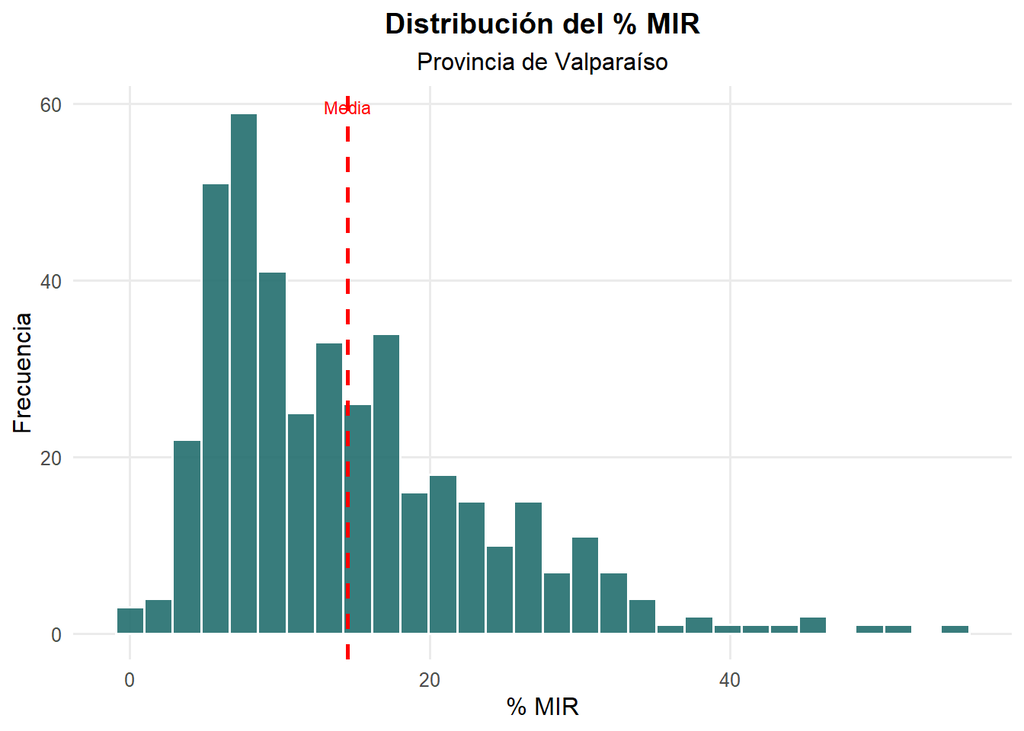

## 4.2 Resultados PES

El porcentaje de población con educación superior muestra un histograma que, al igual que el anterior, presenta asimetría hacia la derecha, aunque menos pronunciada. Se observa una mayor dispersión de valores, con rangos que abarcan la mayoría de los porcentajes posibles.

Las zonas de mayor frecuencia se concentran cercanas al 20% hasta un 35% aproximadamente, lo que implica en la mayoría de las zonas censales, entre un quinto y un tercio de la población con estudios superiores, ya sean técnicos o universitarios. Sin embargo, el gráfico también muestra una cola larga de valores relativamente altos. Se espera que estas zonas se concentres en torno a los centros urbanos consolidados como Viña del Mar y Valparaíso, donde existe una mayor presencia de servicios, universidad y oportunidades laborales calificadas. Por contraste, las zonas con valores bajos de PES corresponden a sectores rurales o periféricos, donde las brechas educativas se mantienen más pronunciadas.

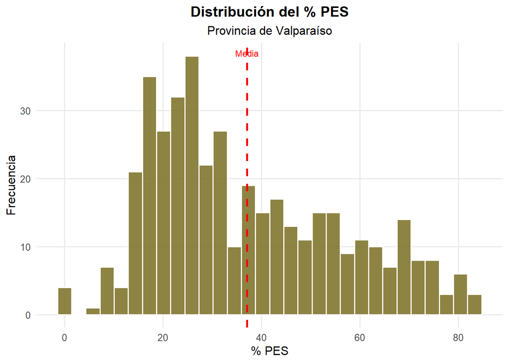

## 4.3 Relación y dispersión

El diagrama de dispersión muestra la relación entre el porcentaje de movilidad intercomunal residencial (MIR) y el porcentaje de población con educación superior (PES) en las zonas censales de la Provincia de Valparaíso. Cada punto representa una zona censal, mientras que la línea roja discontinua indica la tendencia lineal estimada mediante una regresión simple.

El valor del coeficiente de determinación $R²=0.29$ muestra una correlación moderada positiva, lo que a su vez indica que, en términos generales, las zonas con mayor porcentaje de población con educación superior tienden a presentar también una mayor movilidad residencial entre comunas.

Por otra parte, la nube de puntos muestra una fuerte concentración en torno a valores en el cuadrante cercano al origen, lo que corresponde a la mayoría de las zonas censales. En su extremo opuesto, se observan los valores con altos niveles de MIR y PES, donde a priori se espera visualizar estos datos en sectores urbanos consolidados, donde la oferta educativa, el desarrollo inmobiliario y las oportunidades laborales actúan como un factor de atracción.

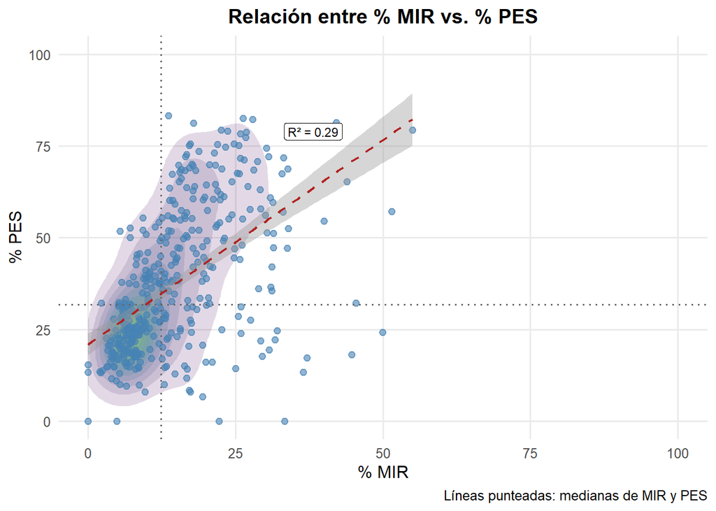

## 4.4 Visualización espacial

### 4.4.1 Distribución espacial % MIR

El mapa evidencia una distribución espacial principalmente heterogénea. Los valores más altos se concentran principalmente en sectores urbanos y periurbanos de las comunas de Quinteros, Concón y Valparaíso, mientras que zonas más interiores como Puchuncaví y Casablanca presentan niveles considerablemente más bajos.

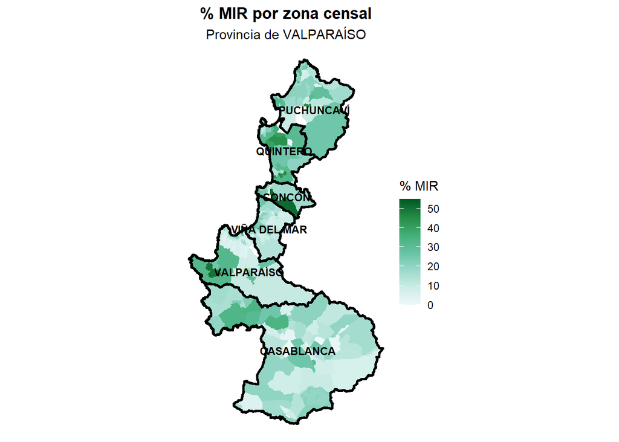

### 4.4.2 Distribución espacial % PES

Este mapa también muestra una alta heterogeneidad en el territorio con respecto a la distribución porcentual de población con educación superior en la provincia. A diferencia de la otra variable, en este caso los valores más alto se concentran en las zonas costeras y de forma aún más marcada, en sectores históricamente asociados a personas de altos recursos, como lo son Viña del Mar, Reñaca y Concón. Para este caso los valores más altos, que superan el 60%, se emplazan en los centros urbanos consolidados, donde existen factores de bienes y servicios que habitualmente atraen a la población con mayores niveles educacionales.

De forma opuesta, en las zonas interiores y rurales, se localizan los valores bajos de PES, donde las oportunidades educativas son más limitadas y la estructura productiva mantiene un carácter principalmente primario.

Este patrón territorial es un reflejo de una centralización del capital educativo en torno al eje metropolitano de la provincia, reproduciendo de alguna manera desigualdades histórica entre polos costeros y comunas interiores.

El gradiente que presenta el mapa no es solo un indicador social, sino que también una expresión del nivel de desarrollo urbano y del acceso diferenciado a los recursos y oportunidades que presentan los territorios.

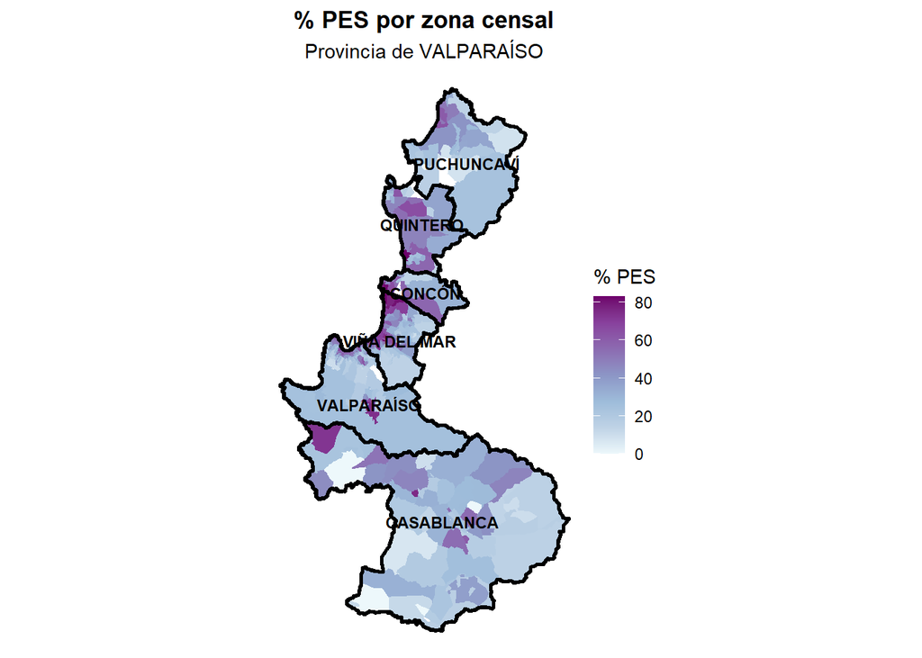

### 4.4.3 Distribución bivariada %MIR - %PES

El mapa bivariado obtenido permite observar la integración de ambas variables desde una perspectiva espacial. Esta visualización es reveladora en cuanto a la identificación de patrones diferenciados entre los sectores costeros e interiores de la provincia.

Los tonos más oscuros muestran zonas donde la movilidad y la educación alcanzan en simultáneo valores altos y, como se puede observar, estos se encuentran principalmente concentrados en el límite de Viña del Mar y Concón, específicamente en la localidad de Reñaca. Del mismo modo, sectores interiores de Valparaíso y Quintero, con nuevos proyectos inmobiliarios, han logrado atraer a población profesional a estas comunas.

Para el caso costero se manifiestan procesos vinculados al fenómeno de la gentrificación, entendida como la llegada de nuevos residentes con mayor capacidad económica, la cual generalmente también se asocia a mayores niveles de educación, que reconfiguran el uso del suelo y desplazan progresivamente a poblaciones de menores ingresos. La combinación de alta movilidad y capital educativo evidencia sectores en transformación, donde la presión inmobiliaria y la búsqueda de localizaciones con buena accesibilidad y servicios generan dinámicas de reemplazo social y encarecimiento de los sectores urbanos.

En contraste a esta situación, los tonos claros y pálidos que corresponden a zonas de baja movilidad y bajo nivel educativo, mantienen una estructura socioespacial más estable, asociada a contextos rurales o economías locales de menor dinamismo.

Finalmente, los tonos intermedios se podría decir que existen zonas de transición funcional, donde las dinámicas propias de la metrópolis comienzan a incidir pero sin modificar completamente en el perfil sociodemográfico. Estas áreas poseen el potencial de convertirse en espacios de expansión de la gentrificación, especialmente en sectores limítrofes a los centros urbanos o en zonas con nuevos proyectos residenciales.

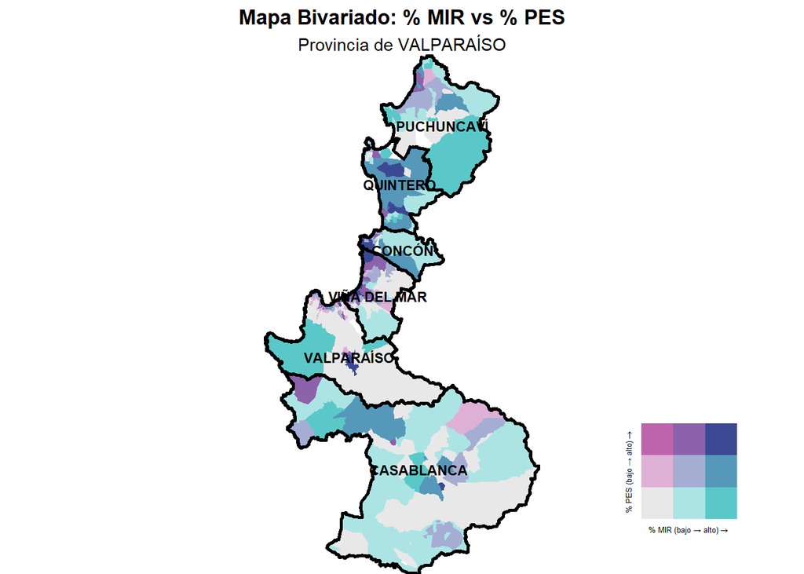

Las variables en conjunto confirman una leve correlación positiva entre la movilidad y educación observada en el análisis estadístico, pero a su vez agrega una lectura más compleja. Los procesos de movilidad residencial no se distribuyen homogéneamente, sino que tienden a concentrase en territorios donde el capital educativo y económico se acumula, reproduciendo desigualdades y generando nuevas formas de segregación urbana y desplazamiento social. De esta forma, la gentrificación aparece no solo como un fenómeno socioeconómico, sino también como una expresión territorial de las brechas educativas y de movilidad dentro del sistema metropolitano porteño.

# 5. Conclusiones

El análisis realizado permitió comprender cómo la movilidad intercomunal residencial se relaciona dentro de la Provincia de Valparaíso, evidenciando una estructura en el territorio marcada por fuertes contrastes socioespaciales.

Los resultados del análisis estadístico mostraron una correlación positiva pero débil entre ambas variables, lo que implica que en las zonas con mayor proporción de población con educación superior tienden a presentar una mayor movilidad residencial. Esto además se interpreta como una manifestación del vínculo entre el capital educativo y capacidad de desplazamiento, donde las personas con mayores recursos educacionales y económicos poseen mayor libertad de elección residencial dentro del sistema metropolitano.

El mapa bivariado integró las variables mostrando que la superposición de alta movilidad y alto nivel educativo coincide con los territorios donde emergen signos de gentrificación. Estos procesos se expresan mediante la llegada de nuevos residentes con mayor poder adquisitivo productivo del nivel educacional asociado, lo que genera una presión sobre los habitantes tradicionales y desplazamientos indirectos. La gentrificación en este contexto se entiende no como un fenómeno aislado, sino como una consecuencia de la interacción entre la movilidad residencial y la desigual distribución del nivel educativo.

Finalmente, los resultados permiten afirmar que la Provincia de Valparaíso presenta un patrón territorial desigual, donde los flujos de movilidad y la concentración educativa refuerzan las dinámicas de centralidad costera y marginación en el interior. Comprender estas relaciones en el territorio resulta clave para orientar políticas públicas que aborden la segregación socioespacial y promuevan un acceso más equitativo a la educación superior.